# Kitchen Sink

Ernesto

May 18, 2017

Rather looking for one optimal policy (say, the optimal MPA), we could simply instruct the optimiser to maximize the score where every possible policy is allowed at once and in any combination. Finding the optimal hybrid policy involves maximizing within the Cartesian product of the parameter spaces of each sub-policy. This optimisation is computationally harder (because the space to search is larger) but it frees the researcher from having to pick the right policy class.

Let’s take the optimal 2-species TAC problem where blue and red fish live in the same areas and fishers cannot avoid catching both at once. When we try to maximise the score:
$$\text{Score} = \sum_{t=1}^{20} \text{Red Landings}_t + \text{Blue Biomass}_{20}$$
the Bayesian posterior of that problem looks something like this:

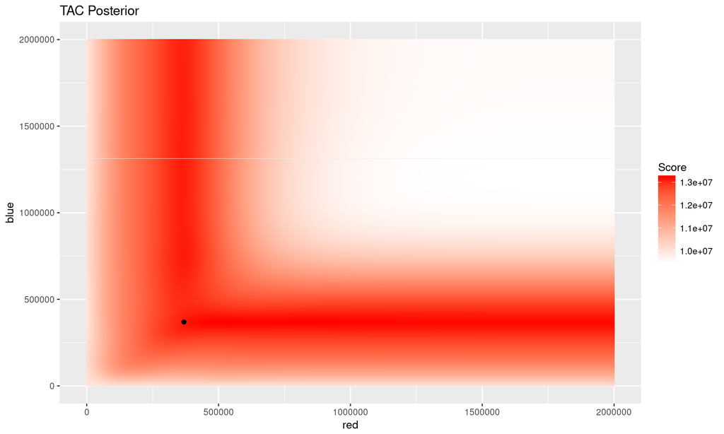

It’s L-shaped both because agents have no way to avoid blue to target red (since they live together) and because global TACs do not provide incentive to switch anyway.

Combining instead three different policies:

- TAC quota
- MPA
- Fishing Season

can we obtain a better score?  
This is a 8 parameter optimisation problem:

| Parameter | Meaning |
| --- | --- |
| Quota Red | Fishery-wide maximum of red fish landed before fishery is closed |
| Quota Blue | Fishery-wide maximum of blue fish landed before fishery is closed |
| Season Length | Maximum number of days before fishery is closed |
| $\text{MPA}_x$ | X coordinate of top left MPA corner on Map |
| $\text{MPA}_y$ | Y coordinate of top left MPA corner on Map |
| MPA height | Heigth (in cells) of the MPA |
| MPA width | Width (in cells) of the MPA |
| MPA duration | Number of days within a year where the MPA is active |

While having more parameters should help in improving the score, we might intuitively assume policy hybrids are not helpful in this scenario for two reasons. First, quotas are already a way to define season length that is more flexible and accurate than day limits and second, both species are uniformly distributed throughout the map making MPAs look pointless.

Surprisingly then, the best hybrid policy scores on average 30% above the optimal TAC alone. The optimal hybrid parameters found by a standard Bayesian Optimisation are:

| Parameter | Meaning |
| --- | --- |
| Quota Red | 508972.658997 |
| Quota Blue | 445740.300354 |
| Season Length | 250 |
| $\text{MPA}_x$ | 19 |
| $\text{MPA}_y$ | 2 |
| MPA height | 36 |
| MPA width | 32 |
| MPA duration | 213 |

First notice that the quota values are higher than what we found when we optimised TAC alone. Notice also that the MPA is very large but lasts 40 days less than the overall fishing season, meaning that fishers can fish within the MPA for a brief period of time. The next figure shows the position of the MPA:

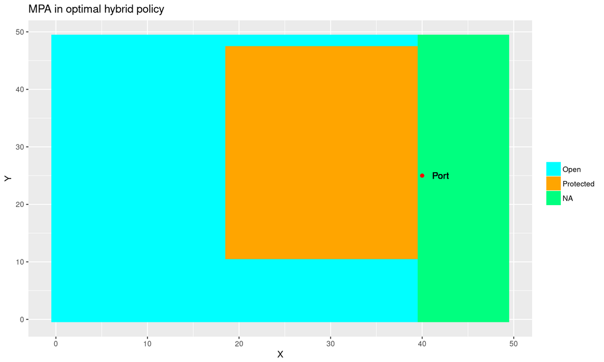

The position of the temporary MPA when using the optimal hybrid policy

The reason this mixture of effort and spatial policy works well is that it exploits, without being explicitly coded to do so, the logistic growth of the biology cells. As shown, without regulations boats generate fishing fronts, depleting cells closest to port. Were the effort more dispersed, fewer cells would be emptied and recruitment would be higher for same amount of global biomass.  
A temporary MPA is a way to somewhat disperse effort. When the MPA is open agents exploit it (since it is close to port and more profitable) but since the MPA is only ever open for a month, the effect is never enough to cause major depletion. For the rest of the year agents mostly fish the line around the MPA which causes some local depletion but there are then about 100 days where fish from both within the MPA and from further out at sea move in the depleted middle before spawning and starting the new season.

The next figure shows red fish dynamics comparing a sample run using the optimal TAC alone versus using the optimal hybrid policy. There are always more red landings with the hybrid policy than with the optimal TAC. This, for the first 5 years, results in biomass being higher in the TAC-only scenario. However because effort is dispersed in the hybrid scenario, recruitment is on average 50% higher (as most cells have some biomass spawning there). The result is that while more red fish is landed, red biomass is 2M units higher by the end of the simulation when using the hybrid policy.

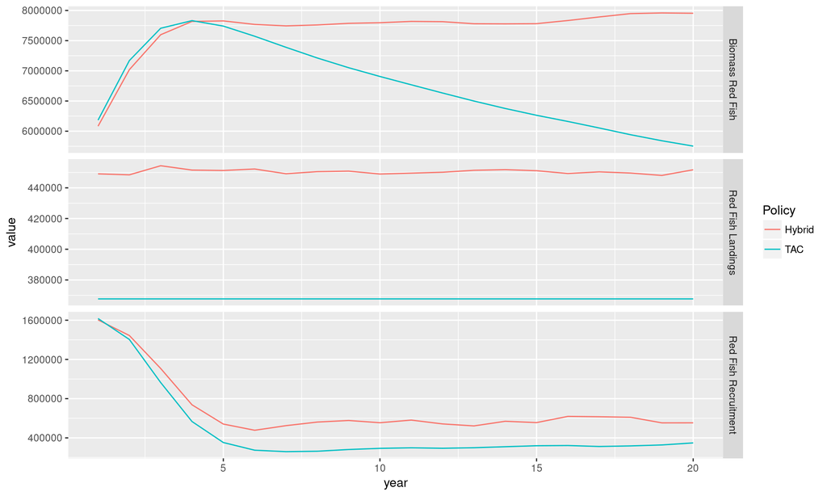

Select dynamics comparing the optimal TAC and the optimal hybrid policy sample runs